# Polinomi u SAGE-u

verzija: SageMath 9.4

```python
load('MMZI.sage')
```

```
Dodatne funkcije za predmet 'Matematicke metode za informaticare'.
MMZI_naredbe je rjecnik u kojemu je po poglavljima dan popis svih dodatnih naredbi koje trenutno postoje.
```

```python
%display latex
```

### 1. zadatak

Odredite polinom trećeg stupnja koji prolazi točkama $(1,3),\, (2,16),\, (-1,1)$ i $(3,45)$.

### Rješenje

```python
R.<x>=QQ[]
f=R.lagrange_polynomial([(1,3),(2,16),(-1,1),(3,45)])
f
```

\[\newcommand{\Bold}[1]{\mathbf{#1}}x^{3} + 2 x^{2}\]

grafički prikaz dobivenog polinoma i zadanih točaka

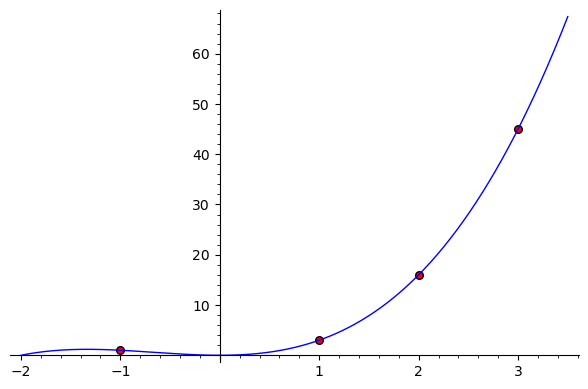

```python
plot(f,-2,3.5)+point(((1,3),(2,16),(-1,1),(3,45)),rgbcolor=(1,0,0),pointsize=30,markeredgecolor='black',faceted=True)
```

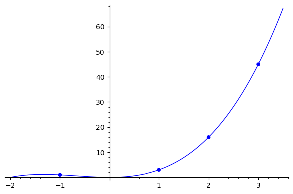

```python
plot(f,-2,3.5)+point(((1,3),(2,16),(-1,1),(3,45)),rgbcolor=(0,0,1),pointsize=30)
```

ili možemo koristiti moćan python modul *matplotlib*

```python
import pylab
import numpy
```

```python
x=numpy.arange(-2.0,3.5,0.01)
y=list(map(f,x))
```

```python
tocke_x = [1,2,-1,3]
tocke_y = [3,16,1,45]
```

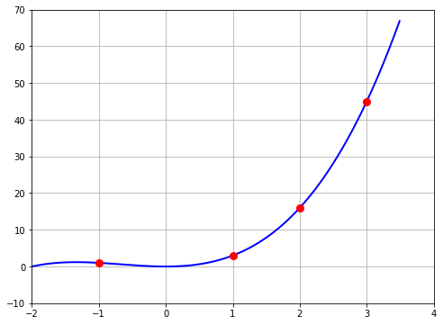

```python
%display plain
pylab.figure(figsize=(8,6))
pylab.axis([-2,4, -10, 70])
pylab.grid(True)
pylab.plot(x,y,'b-',tocke_x,tocke_y,'ro',markersize=8,linewidth=2);
#pylab.savefig('lagrange.png')
```

### 2. zadatak

Uočite na grafu funkcije $y=3^x$ točke $\big(\!-\!1,\frac{1}{3}\big),\, (0,1)$ i $(1,3)$. Nađite polinom najmanjeg stupnja koji prolazi tim točkama i pomoću njega približno odredite $\sqrt[4]{3}$.

### Rješenje

```python
%display latex
R.<x>=QQ[]
g=R.lagrange_polynomial([(-1,1/3),(0,1),(1,3)])
g
```

\[\newcommand{\Bold}[1]{\mathbf{#1}}\frac{2}{3} x^{2} + \frac{4}{3} x + 1\]

grafički prikaz zadane funkcije (crvena boja) i pronađenog polinoma (plava boja) sa istaknutim zadanim točkama

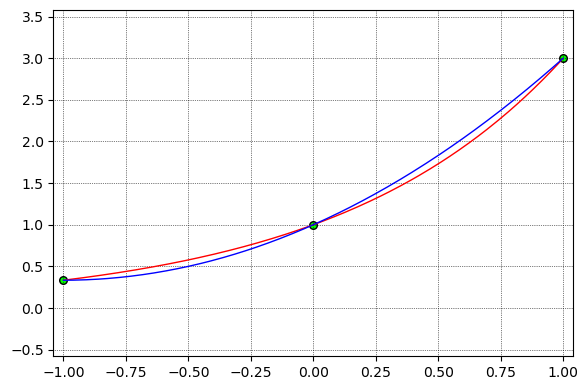

```python
show(plot(lambda x: 3**x,(-1,1),rgbcolor=(1,0,0))+plot(g,-1,1)+
     point(((-1,1/3),(0,1),(1,3)),rgbcolor=(0,1,0),faceted=True,pointsize=30,markeredgecolor='black'),
     frame=True,gridlines=True,axes=False,ymin=-0.5,ymax=3.5,
     ticks=[[-1+0.25*i for i in range(0,9)],[-0.5+0.5*i for i in range(0,9)]])
```

aproksimacija broja $\sqrt[4]{3}$ pomoću dobivenog polinoma

```python
vrijednost=n(3**(1/4),digits=50); vrijednost
```

\[\newcommand{\Bold}[1]{\mathbf{#1}}1.3160740129524924608192189017969990551600685902058\]

```python
aproksimacija=n(g(1/4),digits=50); aproksimacija
```

\[\newcommand{\Bold}[1]{\mathbf{#1}}1.3750000000000000000000000000000000000000000000000\]

greška aproksimacije

```python
vrijednost-aproksimacija
```

\[\newcommand{\Bold}[1]{\mathbf{#1}}-0.058925987047507539180781098203000944839931409794178\]

### 3. zadatak

Odredite kvocijent i ostatak pri dijeljenju polinoma $f(x)=x^5-3x^3-5x$ s polinomom $g(x)=x^2-x+1$.

### Rješenje

```python
R.<x>=QQ[]
f=x^5-3*x^3-5*x
g=x^2-x+1
```

kvocijent

```python
f//g
```

\[\newcommand{\Bold}[1]{\mathbf{#1}}x^{3} + x^{2} - 3 x - 4\]

ostatak

```python
f%g
```

\[\newcommand{\Bold}[1]{\mathbf{#1}}-6 x + 4\]

### 4. zadatak

Koliki je ostatak pri dijeljenju polinoma $f(x)=x^{1987}-2x+5$ s polinomom $g(x)=x-1$?

### Rješenje

Već smo ranije s *R.<x>=QQ[ ]* definirali prsten $R$ polinoma u varijabli $x$ nad poljem racionalnih brojeva pa ne trebamo to svaki puta ispočetka ponovo definirati.

```python
f=x^1987-2*x+5
g=x-1
```

ostatak

```python
f%g
```

\[\newcommand{\Bold}[1]{\mathbf{#1}}4\]

Kod ručnog dijeljenja polinoma $f$ i $g$ predugo bi trajalo određivanje kvocijenta tih dvaju polinoma, no u SAGE-u je to gotovo za manje od jedne sekunde

```python
%display plain
```

```python
time f//g
```

```
CPU times: user 126 µs, sys: 10 µs, total: 136 µs
Wall time: 200 µs
```

```
x^1986 + x^1985 + x^1984 + x^1983 + x^1982 + x^1981 + x^1980 + x^1979 + x^1978 + x^1977 + x^1976 + x^1975 + x^1974 + x^1973 + x^1972 + x^1971 + x^1970 + x^1969 + x^1968 + x^1967 + x^1966 + x^1965 + x^1964 + x^1963 + x^1962 + x^1961 + x^1960 + x^1959 + x^1958 + x^1957 + x^1956 + x^1955 + x^1954 + x^1…
```

```python
%display latex
```

### 5. zadatak

Odredite ostatak pri dijeljenju polinoma $f(x)=x^{77}+x^{55}+x^{33}+x^{11}+1$ s polinomom $g(x)=x^2-1$.

### Rješenje

```python
f=x^77+x^55+x^33+x^11+1
g=x^2-1
```

ostatak

```python
f%g
```

\[\newcommand{\Bold}[1]{\mathbf{#1}}4 x + 1\]

nije problem odrediti i kvocijent

```python
f//g
```

\[\newcommand{\Bold}[1]{\mathbf{#1}}x^{75} + x^{73} + x^{71} + x^{69} + x^{67} + x^{65} + x^{63} + x^{61} + x^{59} + x^{57} + x^{55} + 2 x^{53} + 2 x^{51} + 2 x^{49} + 2 x^{47} + 2 x^{45} + 2 x^{43} + 2 x^{41} + 2 x^{39} + 2 x^{37} + 2 x^{35} + 2 x^{33} + 3 x^{31} + 3 x^{29} + 3 x^{27} + 3 x^{25} + 3 x^{23} + 3 x^{21} + 3 x^{19} + 3 x^{17} + 3 x^{15} + 3 x^{13} + 3 x^{11} + 4 x^{9} + 4 x^{7} + 4 x^{5} + 4 x^{3} + 4 x\]

### 6. zadatak

Izračunajte vrijednost polinoma $f(x)=4x^4+2x^2+1$ u točki $2$.

### Rješenje

```python
f=4*x^4+2*x^2+1
```

```python
f(2)
```

\[\newcommand{\Bold}[1]{\mathbf{#1}}73\]

Možemo koristiti funkciju iz datoteke *MMZI.sage*. Funkcija *rucni_Horner(p,x0)* računa vrijednost polinoma $p$ u točki $x_0$ i na izlazu vraća tablicu koju dobivamo ručnim izvođenjem Hornerovog algoritma. Pazite, varijabla *p* mora biti tipa "SAGE polinom".

```python
rucni_Horner(f,2)
```

[output not shown]

### 7. zadatak

Polinom $P(x)=x^4-8x^3+5x^2+2x-7$ razvijte po potencijama od $x+2$.

### Rješenje

```python
x=var('x')
P=x^4-8*x^3+5*x^2+2*x-7
```

```python
P.series(x==-2,5)
```

\[\newcommand{\Bold}[1]{\mathbf{#1}}89 + {(-146)} {(x + 2)} + 77 {(x + 2)}^{2} + {(-16)} {(x + 2)}^{3} + 1 {(x + 2)}^{4} + \mathcal{O}\left({\left(x + 2\right)}^{5}\right)\]

Možemo koristiti funkciju iz datoteke *MMZI.sage*. Funkcija *razvoj_Horner(p,x0)* daje razvoj polinoma $p$ po potencijama od $x-x_0$, tj. daje nam tablicu koju dobivamo ručnim rješavanjem zadatka. Pazite, varijabla *p* mora biti tipa "SAGE polinom".

```python
R.<x>=QQ[]
razvoj_Horner(x^4-8*x^3+5*x^2+2*x-7,-2)
```

|  | \(1\) | \(-8\) | \(5\) | \(2\) | \(-7\) |
| --- | --- | --- | --- | --- | --- |
| \(-2\) | \(1\) | \(-10\) | \(25\) | \(-48\) | \(89\) |
| \(-2\) | \(1\) | \(-12\) | \(49\) | \(-146\) |  |
| \(-2\) | \(1\) | \(-14\) | \(77\) |  |  |
| \(-2\) | \(1\) | \(-16\) |  |  |  |
| \(-2\) | \(1\) |  |  |  |  |

### 8. zadatak

Za polinome $A(x)=x^4+6x^3+17x^2+24x+12$ i $B(x)=x^3-2x^2-13x-10$ odredite polinome $P$ i $Q$ tako da vrijedi $AP+BQ=M(A,B)$.

### Rješenje

```python
R.<x>=QQ[]
A=x^4+6*x^3+17*x^2+24*x+12
B=x^3-2*x^2-13*x-10
```

ako nas zanima samo najveća zajednička mjera

```python
A.gcd(B)
```

\[\newcommand{\Bold}[1]{\mathbf{#1}}x^{2} + 3 x + 2\]

```python
gcd(A,B)
```

\[\newcommand{\Bold}[1]{\mathbf{#1}}x^{2} + 3 x + 2\]

ako nas zanima sve: $M(A,B),\, P,\ Q$

```python
A.xgcd(B)
```

\[\newcommand{\Bold}[1]{\mathbf{#1}}\left(x^{2} + 3 x + 2, \frac{1}{46}, -\frac{1}{46} x - \frac{4}{23}\right)\]

```python
xgcd(A,B)
```

\[\newcommand{\Bold}[1]{\mathbf{#1}}\left(x^{2} + 3 x + 2, \frac{1}{46}, -\frac{1}{46} x - \frac{4}{23}\right)\]

Možemo koristiti funkciju iz datoteke *MMZI.sage*. Funkcija *polinomi_gcd(f,g)* daje svaki korak Euklidovog algoritma prilikom određivanja najveće zajedničke mjere polinoma *f* i *g*, tj. u svakom koraku daje kvocijent i ostatak koji se dobiju dijeljenjem odgovarajućih polinoma, baš onako kako dobivamo ručnim određivanjem najveće zajedničke mjere dva polinoma. Pazite, varijable *f* i *g* moraju biti tipa "SAGE polinom".

```python
polinomi_gcd(A,B)
```

| korak | ------------------- kvocijent ------------------- | ------------------- ostatak ------------------- |
| --- | --- | --- |
| 1. | \(x + 8\) | \(46 x^{2} + 138 x + 92\) |
| 2. | \(\frac{1}{46} x - \frac{5}{46}\) | \(0\) |

### 9. zadatak

Za polinome $A(x)=4x^5-x^4-4x^3+13x^2-3x$ i $B(x)=3x^4-x^3-3x^2+10x-3$ odredite polinome $P$ i $Q$ tako da vrijedi $AP+BQ=M(A,B)$.

### Rješenje

```python
A=4*x^5-x^4-4*x^3+13*x^2-3*x
B=3*x^4-x^3-3*x^2+10*x-3
```

najveća zajednička mjera

```python
gcd(A,B)
```

\[\newcommand{\Bold}[1]{\mathbf{#1}}x^{3} - x + 3\]

ako nas sve zanima: $M(A,B),\, P,\, Q$

```python
xgcd(A,B)
```

\[\newcommand{\Bold}[1]{\mathbf{#1}}\left(x^{3} - x + 3, 9, -12 x - 1\right)\]

pojedini koraci Euklidovog algoritma

```python
polinomi_gcd(A,B)
```

| korak | ------------------- kvocijent ------------------- | ------------------- ostatak ------------------- |
| --- | --- | --- |
| 1. | \(\frac{4}{3} x + \frac{1}{9}\) | \(\frac{1}{9} x^{3} - \frac{1}{9} x + \frac{1}{3}\) |
| 2. | \(27 x - 9\) | \(0\) |

### 10. zadatak

Dokažite da se razlomak $\dfrac{x^4+x^3+1}{x^5+x+1}$ ne može više skratiti.

### Rješenje

Razlomak se ne može više skratiti zato jer je najveća zajednička mjera brojnika i nazivnika jednaka 1.

```python
gcd(x^5+x+1,x^4+x^3+1)
```

\[\newcommand{\Bold}[1]{\mathbf{#1}}1\]

pojedini koraci Euklidovog algoritma

```python
polinomi_gcd(x^5+x+1,x^4+x^3+1)
```

| korak | ------------------- kvocijent ------------------- | ------------------- ostatak ------------------- |
| --- | --- | --- |
| 1. | \(x - 1\) | \(x^{3} + 2\) |
| 2. | \(x + 1\) | \(-2 x - 1\) |
| 3. | \(-\frac{1}{2} x^{2} + \frac{1}{4} x - \frac{1}{8}\) | \(\frac{15}{8}\) |
| 4. | \(-\frac{16}{15} x - \frac{8}{15}\) | \(0\) |

### 11. zadatak

Riješite jednadžbu $5x^3-9x^2-x-2=0$.

### Rješenje

```python
f=5*x^3-9*x^2-x-2
```

Možemo dobiti listu intervala unutar kojih se nalaze realne nultočke. Konkretno ovdje, naš polinom ima samo jednu realnu nultočku unutar intervala $\big\langle\frac{3}{2},\frac{11}{4}\big\rangle$.

```python
f.real_root_intervals()
```

\[\newcommand{\Bold}[1]{\mathbf{#1}}\left[\left(\left(\frac{3}{2}, \frac{11}{4}\right), 1\right)\right]\]

Sa slike bismo mogli očitati da bi ta realna nultočka bila $x=2$, što i direktnim provjeravanjem zaista jest.

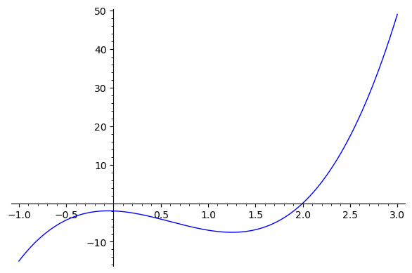

```python
plot(f,-1,3)
```

Daje samo racionalne nultočke polinoma $f$ jer je polinom $f$ definiran kao polinom s racionalnim koeficijentima. Sjetimo se da smo ranije definirali *R.<x>=QQ[ ]*. $x=2$ je jednostruka nultočka.

```python
f.roots()
```

\[\newcommand{\Bold}[1]{\mathbf{#1}}\left[\left(2, 1\right)\right]\]

Daje sve realne nultočke od $f$. Uočavamo da $f$ ima samo jednu realnu jednostruku nultočku.

```python
f.roots(RR)
```

\[\newcommand{\Bold}[1]{\mathbf{#1}}\left[\left(2.00000000000000, 1\right)\right]\]

```python
f.roots(RealField(200))
```

\[\newcommand{\Bold}[1]{\mathbf{#1}}\left[\left(2.0000000000000000000000000000000000000000000000000000000000, 1\right)\right]\]

Daje sve kompleksne nultočke

```python
f.roots(CC)
```

\[\newcommand{\Bold}[1]{\mathbf{#1}}\left[\left(2.00000000000000, 1\right), \left(-0.100000000000000 - 0.435889894354067i, 1\right), \left(-0.100000000000000 + 0.435889894354067i, 1\right)\right]\]

```python
f.roots(ComplexField(200))
```

\[\newcommand{\Bold}[1]{\mathbf{#1}}\left[\left(2.0000000000000000000000000000000000000000000000000000000000, 1\right), \left(-0.10000000000000000000000000000000000000000000000000000000000 - 0.43588989435406735522369819838596156591370039252324449368903i, 1\right), \left(-0.10000000000000000000000000000000000000000000000000000000000 + 0.43588989435406735522369819838596156591370039252324449368903i, 1\right)\right]\]

možemo koristiti i naredbu *solve*

```python
u=var('u')
solve(5*u^3-9*u^2-u-2,u)
```

\[\newcommand{\Bold}[1]{\mathbf{#1}}\left[u = -\frac{1}{10} i \, \sqrt{19} - \frac{1}{10}, u = \frac{1}{10} i \, \sqrt{19} - \frac{1}{10}, u = 2\right]\]

ili

```python
solve([5*u^3-9*u^2-u-2==0],u)
```

\[\newcommand{\Bold}[1]{\mathbf{#1}}\left[u = -\frac{1}{10} i \, \sqrt{19} - \frac{1}{10}, u = \frac{1}{10} i \, \sqrt{19} - \frac{1}{10}, u = 2\right]\]

**Napomena.** Ako promatramo polinom $g(x)=x^2-2$, tada je dolje polinom $g$ definiran kao polinom s racionalnim koeficijentima jer smo već ranije definirali *R.<x>=QQ[ ]*.

```python
g=x^2-2
```

polinom $g$ nema racionalnih nultočaka

```python
g.roots()
```

\[\newcommand{\Bold}[1]{\mathbf{#1}}\left[\right]\]

```python
g.roots(QQ)
```

\[\newcommand{\Bold}[1]{\mathbf{#1}}\left[\right]\]

polinom $g$ ima dvije jednostruke realne nultočke

```python
g.roots(RR)
```

\[\newcommand{\Bold}[1]{\mathbf{#1}}\left[\left(-1.41421356237310, 1\right), \left(1.41421356237310, 1\right)\right]\]

```python
g.roots(RealField(300))
```

\[\newcommand{\Bold}[1]{\mathbf{#1}}\left[\left(-1.41421356237309504880168872420969807856967187537694807317667973799073247846210703885038753, 1\right), \left(1.41421356237309504880168872420969807856967187537694807317667973799073247846210703885038753, 1\right)\right]\]

### 12. zadatak

Riješite jednadžbu $2x^4+13x^3+25x^2+15x+9=0$.

### Rješenje

```python
f=2*x^4+13*x^3+25*x^2+15*x+9
```

Pogledajmo intervale u kojima se nalaze realne nultočke

```python
f.real_root_intervals()
```

\[\newcommand{\Bold}[1]{\mathbf{#1}}\left[\left(\left(-\frac{965829028745320677378189160381}{321943009581773547211778324968}, -\frac{1931658057490640389699315312795}{643886019163547094423556649936}\right), 2\right)\right]\]

```python
f.real_root_intervals()[0][0]
```

\[\newcommand{\Bold}[1]{\mathbf{#1}}\left(-\frac{965829028745320677378189160381}{321943009581773547211778324968}, -\frac{1931658057490640389699315312795}{643886019163547094423556649936}\right)\]

pogledajmo numerički koji je to zapravo interval

```python
[n(i,digits=50) for i in f.real_root_intervals()[0][0]]
```

\[\newcommand{\Bold}[1]{\mathbf{#1}}\left[-3.0000000000000001110223024625055960658215989396981, -2.9999999999999986122212192185433790254004733833419\right]\]

Dakle, unutar gornjeg intervala imamo dvije realne nultočke, a kako je taj interval jako mali već predosjećamo da bi $x=-3$ mogla biti dvostruka nultočka (naravno, to je samo naša slutnja, što ne znači da mora biti i istinita). Pogledajmo i graf koji će nas još više u to uvjeriti (uočite kako graf "dodiruje" u točki $(-3,0)$ $x$-os, što zapravo znači da je $-3$ dvostruka nultočka).

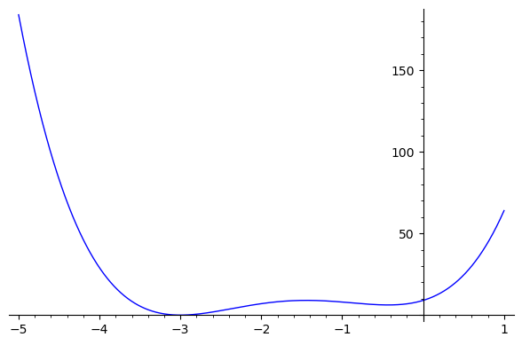

```python
plot(f,-5,1)
```

potvrdimo konačno naše slutnje

```python
f.roots(RR)
```

\[\newcommand{\Bold}[1]{\mathbf{#1}}\left[\left(-3.00000000000000, 2\right)\right]\]

```python
f.roots(CC)
```

\[\newcommand{\Bold}[1]{\mathbf{#1}}\left[\left(-3.00000000000000, 2\right), \left(-0.250000000000000 - 0.661437827766148i, 1\right), \left(-0.250000000000000 + 0.661437827766148i, 1\right)\right]\]

```python
solve(2*u^4+13*u^3+25*u^2+15*u+9,u)
```

\[\newcommand{\Bold}[1]{\mathbf{#1}}\left[u = -\frac{1}{4} i \, \sqrt{7} - \frac{1}{4}, u = \frac{1}{4} i \, \sqrt{7} - \frac{1}{4}, u = \left(-3\right)\right]\]

faktorizacija polinoma $f$

```python
factor(f)
```

\[\newcommand{\Bold}[1]{\mathbf{#1}}\left(2\right) \cdot (x + 3)^{2} \cdot (x^{2} + \frac{1}{2} x + \frac{1}{2})\]

### 13. zadatak

Riješite jednadžbu $x^3+3x^2-9x-20=0$.

### Rješenje

```python
f=x^3+3*x^2-9*x-20
```

Idemo se opet malo igrati. Pogledajmo prvo intervale u kojima se nalaze realne nultočke.

```python
f.real_root_intervals()
```

\[\newcommand{\Bold}[1]{\mathbf{#1}}\left[\left(\left(-\frac{35}{8}, -\frac{63}{16}\right), 1\right), \left(\left(-\frac{7}{2}, -\frac{7}{4}\right), 1\right), \left(\left(0, \frac{7}{2}\right), 1\right)\right]\]

Dakle, naš polinom ima tri realne nultočke, što možemo vidjeti i sa grafa.

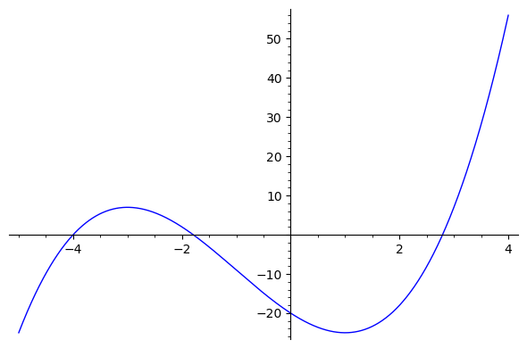

```python
plot(f,-5,4)
```

sve realne nultočke

```python
f.roots(RR)
```

\[\newcommand{\Bold}[1]{\mathbf{#1}}\left[\left(-4.00000000000000, 1\right), \left(-1.79128784747792, 1\right), \left(2.79128784747792, 1\right)\right]\]

```python
solve(u^3+3*u^2-9*u-20,u)
```

\[\newcommand{\Bold}[1]{\mathbf{#1}}\left[u = -\frac{1}{2} \, \sqrt{21} + \frac{1}{2}, u = \frac{1}{2} \, \sqrt{21} + \frac{1}{2}, u = \left(-4\right)\right]\]

### 14. zadatak

Riješite jednadžbu $x^4-4x^3+11x^2-14x+10=0$.

### Rješenje

```python
f=x^4-4*x^3+11*x^2-14*x+10
```

$f$ nema realnih nultočaka

```python
f.real_root_intervals()
```

\[\newcommand{\Bold}[1]{\mathbf{#1}}\left[\right]\]

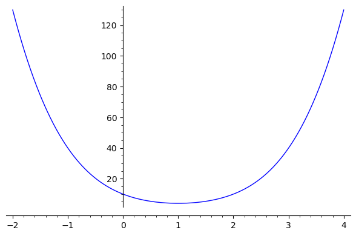

```python
plot(f,-2,4)
```

```python
f.roots(CC)
```

\[\newcommand{\Bold}[1]{\mathbf{#1}}\left[\left(1.00000000000000 - 2.00000000000000i, 1\right), \left(1.00000000000000 - 1.00000000000000i, 1\right), \left(1.00000000000000 + 1.00000000000000i, 1\right), \left(1.00000000000000 + 2.00000000000000i, 1\right)\right]\]

```python
solve(u^4-4*u^3+11*u^2-14*u+10,u)
```

\[\newcommand{\Bold}[1]{\mathbf{#1}}\left[u = \left(-2 i + 1\right), u = \left(2 i + 1\right), u = \left(-i + 1\right), u = \left(i + 1\right)\right]\]

### 15. zadatak

Izračunajte $\big(i-\sqrt{3}\big)^{13}$.

### Rješenje

```python
expand((I-sqrt(3))^13)
```

\[\newcommand{\Bold}[1]{\mathbf{#1}}-4096 \, \sqrt{3} + 4096 i\]

### 16. zadatak

Riješite jednadžbu $8x^5-4x^4+2x^3-7x^2+5x-1=0$.

### Rješenje

```python
f=8*x^5-4*x^4+2*x^3-7*x^2+5*x-1
```

postoje tri realne nultočke

```python
f.real_root_intervals()
```

\[\newcommand{\Bold}[1]{\mathbf{#1}}\left[\left(\left(\frac{461168601842739593}{922337203685479424}, \frac{922337203685479817}{1844674407370958848}\right), 3\right)\right]\]

```python
[n(k,digits=50) for k in f.real_root_intervals()[0][0]]
```

\[\newcommand{\Bold}[1]{\mathbf{#1}}\left[0.49999999999999987097994147422523018698442153716151, 0.50000000000000021304572689340119553157614426846860\right]\]

naslućujemo da bi $\frac{1}{2}$ mogla biti trostruka nultočka

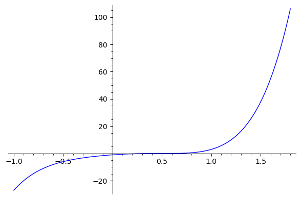

```python
plot(f,-1,1.8)
```

sve nultočke

```python
f.roots(CC)
```

\[\newcommand{\Bold}[1]{\mathbf{#1}}\left[\left(0.500000000000000, 3\right), \left(-0.500000000000000 - 0.866025403784439i, 1\right), \left(-0.500000000000000 + 0.866025403784439i, 1\right)\right]\]

```python
solve(8*u^5-4*u^4+2*u^3-7*u^2+5*u-1,u)
```

\[\newcommand{\Bold}[1]{\mathbf{#1}}\left[u = -\frac{1}{2} i \, \sqrt{3} - \frac{1}{2}, u = \frac{1}{2} i \, \sqrt{3} - \frac{1}{2}, u = \left(\frac{1}{2}\right)\right]\]

```python
solve(8*u^5-4*u^4+2*u^3-7*u^2+5*u-1,u,multiplicities=True)
```

\[\newcommand{\Bold}[1]{\mathbf{#1}}\left(\left[u = -\frac{1}{2} i \, \sqrt{3} - \frac{1}{2}, u = \frac{1}{2} i \, \sqrt{3} - \frac{1}{2}, u = \left(\frac{1}{2}\right)\right], \left[1, 1, 3\right]\right)\]

faktorizacija polinoma $f$

```python
factor(f)
```

\[\newcommand{\Bold}[1]{\mathbf{#1}}\left(8\right) \cdot (x - \frac{1}{2})^{3} \cdot (x^{2} + x + 1)\]

### 17. zadatak

Riješite jednadžbu $x^3-3x^2+3=0$.

### Rješenje

S naredbom *solve* nećemo baš nešto pametno dobiti.

```python
solve(u^3-3*u^2+3,u)
```

\[\newcommand{\Bold}[1]{\mathbf{#1}}\left[u = -\frac{1}{2} \, {\left(i \, \sqrt{3} + 1\right)} {\left(\frac{1}{2} i \, \sqrt{3} - \frac{1}{2}\right)}^{\frac{1}{3}} + {\left(\frac{1}{2} i \, \sqrt{3} - \frac{1}{2}\right)}^{\frac{2}{3}} + 1, u = {\left(\frac{1}{2} i \, \sqrt{3} - \frac{1}{2}\right)}^{\frac{4}{3}} - \frac{i \, \sqrt{3} + 1}{2 \, {\left(\frac{1}{2} i \, \sqrt{3} - \frac{1}{2}\right)}^{\frac{1}{3}}} + 1, u = {\left(\frac{1}{2} i \, \sqrt{3} - \frac{1}{2}\right)}^{\frac{1}{3}} + \frac{1}{{\left(\frac{1}{2} i \, \sqrt{3} - \frac{1}{2}\right)}^{\frac{1}{3}}} + 1\right]\]

Preko metode *roots* dobivamo numerička rješenja i uočavamo da zadana jednadžba ima tri različita realna rješenja.

```python
f=x^3-3*x^2+3
```

```python
f.roots(CC)
```

\[\newcommand{\Bold}[1]{\mathbf{#1}}\left[\left(-0.879385241571817, 1\right), \left(1.34729635533386, 1\right), \left(2.53208888623796, 1\right)\right]\]

### 18. zadatak

Riješite jednadžbu $z^3+i=0$.

### Rješenje

U ovom slučaju *solve* i *roots* ne daju ono što bismo željeli.

```python
solve(u^3+I,u)
```

\[\newcommand{\Bold}[1]{\mathbf{#1}}\left[u = \frac{1}{2} i \, \sqrt{3} \left(-i\right)^{\frac{1}{3}} - \frac{1}{2} \, \left(-i\right)^{\frac{1}{3}}, u = -\frac{1}{2} i \, \sqrt{3} \left(-i\right)^{\frac{1}{3}} - \frac{1}{2} \, \left(-i\right)^{\frac{1}{3}}, u = \left(-i\right)^{\frac{1}{3}}\right]\]

```python
R1.<c>=CC[]
f=c^3+I
```

```python
f.roots()
```

\[\newcommand{\Bold}[1]{\mathbf{#1}}\left[\left(-0.866025403784439 - 0.500000000000000i, 1\right), \left(1.00000000000000i, 1\right), \left(0.866025403784439 - 0.500000000000000i, 1\right)\right]\]

Međutim, SAGE ima naredbu *complex_roots* koja će obaviti posao kako treba

```python
from sage.rings.polynomial.complex_roots import *
```

```python
R.<x>=QQ[]
K.<i>=NumberField(x^2+1)
```

```python
complex_roots(x^3+i)
```

\[\newcommand{\Bold}[1]{\mathbf{#1}}\left[\left(-0.866025403784439? - 0.500000000000000?i, 1\right), \left(1i, 1\right), \left(0.866025403784439? - 0.500000000000000?i, 1\right)\right]\]

ili možemo koristiti metodu *nth_root* za vađenje $n$-tog korijena iz kompleksnog broja. Ovdje zapravo treba izračunati $\sqrt[3]{-i}$.

```python
a = CC(-I)
a.nth_root(3,all=True)
```

\[\newcommand{\Bold}[1]{\mathbf{#1}}\left[0.866025403784439 - 0.500000000000000i, 6.12323399573677 \times 10^{-17} + 1.00000000000000i, -0.866025403784439 - 0.500000000000000i\right]\]

Možemo koristiti funkciju iz datoteke *MMZI.sage*. Funkcija *kompleksni_korijen(z,n,sredi=False)* daje sve $n$-te korijene kompleksnog broja $z$. Varijabla *sredi* po defaultu je stavljena na *False*, što znači da se neće sređivati kosinusi i sinusi "lijepih" kutova. Ako želimo da se srede kosinusi i sinusi "lijepih" kutova, tada treba staviti *sredi=True*.

primjena funkcije *kompleksni_korijen* na računanje $\sqrt[3]{-i}$

```python
kompleksni_korijen(-I,3)
```

\[\newcommand{\Bold}[1]{\mathbf{#1}}\left[\cos\left(\frac{1}{2} \, \pi\right) + i \, \sin\left(\frac{1}{2} \, \pi\right), \cos\left(\frac{7}{6} \, \pi\right) + i \, \sin\left(\frac{7}{6} \, \pi\right), \cos\left(\frac{11}{6} \, \pi\right) + i \, \sin\left(\frac{11}{6} \, \pi\right)\right]\]

```python
kompleksni_korijen(-I,3,sredi=True)
```

\[\newcommand{\Bold}[1]{\mathbf{#1}}\left[\cos\left(\frac{1}{2} \, \pi\right) + i \, \sin\left(\frac{1}{2} \, \pi\right), -\frac{1}{2} \, \sqrt{3} - \frac{1}{2} i, \frac{1}{2} \, \sqrt{3} - \frac{1}{2} i\right]\]

### Još nekoliko primjera korištenja funkcije *kompleksni_korijen*

$\sqrt[5]{9}$

```python
kompleksni_korijen(9,5)
```

\[\newcommand{\Bold}[1]{\mathbf{#1}}\left[9^{\frac{1}{5}} {\left(\cos\left(0\right) + i \, \sin\left(0\right)\right)}, 9^{\frac{1}{5}} {\left(\cos\left(\frac{2}{5} \, \pi\right) + i \, \sin\left(\frac{2}{5} \, \pi\right)\right)}, 9^{\frac{1}{5}} {\left(\cos\left(\frac{4}{5} \, \pi\right) + i \, \sin\left(\frac{4}{5} \, \pi\right)\right)}, 9^{\frac{1}{5}} {\left(\cos\left(\frac{6}{5} \, \pi\right) + i \, \sin\left(\frac{6}{5} \, \pi\right)\right)}, 9^{\frac{1}{5}} {\left(\cos\left(\frac{8}{5} \, \pi\right) + i \, \sin\left(\frac{8}{5} \, \pi\right)\right)}\right]\]

```python
kompleksni_korijen(9,5,sredi=True)
```

\[\newcommand{\Bold}[1]{\mathbf{#1}}\left[9^{\frac{1}{5}} {\left(\cos\left(0\right) + i \, \sin\left(0\right)\right)}, \frac{1}{4} \cdot 9^{\frac{1}{5}} {\left(\sqrt{5} + i \, \sqrt{2 \, \sqrt{5} + 10} - 1\right)}, -\frac{1}{4} \cdot 9^{\frac{1}{5}} {\left(\sqrt{5} - i \, \sqrt{-2 \, \sqrt{5} + 10} + 1\right)}, -\frac{1}{4} \cdot 9^{\frac{1}{5}} {\left(\sqrt{5} + i \, \sqrt{-2 \, \sqrt{5} + 10} + 1\right)}, \frac{1}{4} \cdot 9^{\frac{1}{5}} {\left(\sqrt{5} - i \, \sqrt{2 \, \sqrt{5} + 10} - 1\right)}\right]\]

$\sqrt[3]{-\frac{1}{2}+\frac{\sqrt{3}}{2}i}$

```python
kompleksni_korijen(-1/2+sqrt(3)/2*I,3)
```

\[\newcommand{\Bold}[1]{\mathbf{#1}}\left[\cos\left(\frac{2}{9} \, \pi\right) + i \, \sin\left(\frac{2}{9} \, \pi\right), \cos\left(\frac{8}{9} \, \pi\right) + i \, \sin\left(\frac{8}{9} \, \pi\right), \cos\left(\frac{14}{9} \, \pi\right) + i \, \sin\left(\frac{14}{9} \, \pi\right)\right]\]

```python
kompleksni_korijen(-1/2+sqrt(3)/2*I,3,sredi=True)
```

\[\newcommand{\Bold}[1]{\mathbf{#1}}\left[\cos\left(\frac{2}{9} \, \pi\right) + i \, \sin\left(\frac{2}{9} \, \pi\right), -\cos\left(\frac{1}{9} \, \pi\right) + i \, \sin\left(\frac{1}{9} \, \pi\right), \cos\left(\frac{4}{9} \, \pi\right) - i \, \sin\left(\frac{4}{9} \, \pi\right)\right]\]

$\sqrt[7]{-2-2i}$

```python
kompleksni_korijen(-2-2*I,7)
```

\[\newcommand{\Bold}[1]{\mathbf{#1}}\left[2^{\frac{3}{14}} {\left(\cos\left(\frac{5}{28} \, \pi\right) + i \, \sin\left(\frac{5}{28} \, \pi\right)\right)}, 2^{\frac{3}{14}} {\left(\cos\left(\frac{13}{28} \, \pi\right) + i \, \sin\left(\frac{13}{28} \, \pi\right)\right)}, 2^{\frac{3}{14}} {\left(\cos\left(\frac{3}{4} \, \pi\right) + i \, \sin\left(\frac{3}{4} \, \pi\right)\right)}, 2^{\frac{3}{14}} {\left(\cos\left(\frac{29}{28} \, \pi\right) + i \, \sin\left(\frac{29}{28} \, \pi\right)\right)}, 2^{\frac{3}{14}} {\left(\cos\left(\frac{37}{28} \, \pi\right) + i \, \sin\left(\frac{37}{28} \, \pi\right)\right)}, 2^{\frac{3}{14}} {\left(\cos\left(\frac{45}{28} \, \pi\right) + i \, \sin\left(\frac{45}{28} \, \pi\right)\right)}, 2^{\frac{3}{14}} {\left(\cos\left(\frac{53}{28} \, \pi\right) + i \, \sin\left(\frac{53}{28} \, \pi\right)\right)}\right]\]

$\sqrt[4]{1-5i}$

```python
kompleksni_korijen(1-5*I,4)
```

\[\newcommand{\Bold}[1]{\mathbf{#1}}\left[26^{\frac{1}{8}} {\left(\cos\left(\frac{1}{2} \, \pi - \frac{1}{4} \, \arctan\left(5\right)\right) + i \, \sin\left(\frac{1}{2} \, \pi - \frac{1}{4} \, \arctan\left(5\right)\right)\right)}, 26^{\frac{1}{8}} {\left(\cos\left(\pi - \frac{1}{4} \, \arctan\left(5\right)\right) + i \, \sin\left(\pi - \frac{1}{4} \, \arctan\left(5\right)\right)\right)}, 26^{\frac{1}{8}} {\left(\cos\left(\frac{3}{2} \, \pi - \frac{1}{4} \, \arctan\left(5\right)\right) + i \, \sin\left(\frac{3}{2} \, \pi - \frac{1}{4} \, \arctan\left(5\right)\right)\right)}, 26^{\frac{1}{8}} {\left(\cos\left(2 \, \pi - \frac{1}{4} \, \arctan\left(5\right)\right) + i \, \sin\left(2 \, \pi - \frac{1}{4} \, \arctan\left(5\right)\right)\right)}\right]\]

### 19. zadatak

Riješite jednadžbu $(1+i)x^4-(1-i)x=0$.

### Rješenje

```python
complex_roots((1+i)*x^4-(1-i)*x)
```

\[\newcommand{\Bold}[1]{\mathbf{#1}}\left[\left(0, 1\right), \left(-0.866025403784439? - 0.500000000000000?i, 1\right), \left(1i, 1\right), \left(0.866025403784439? - 0.500000000000000?i, 1\right)\right]\]

```python
solve((1+I)*u^4-(1-I)*u,u)
```

\[\newcommand{\Bold}[1]{\mathbf{#1}}\left[u = \frac{1}{2} i \, \sqrt{3} \left(-i\right)^{\frac{1}{3}} - \frac{1}{2} \, \left(-i\right)^{\frac{1}{3}}, u = -\frac{1}{2} i \, \sqrt{3} \left(-i\right)^{\frac{1}{3}} - \frac{1}{2} \, \left(-i\right)^{\frac{1}{3}}, u = \left(-i\right)^{\frac{1}{3}}, u = 0\right]\]

Možemo primijeniti funkciju *kompleksni_korijen*. Naime, jedno rješenje jednadžbe je $x=0$ pa ostaje još riješiti jednadžbu $x^3=\frac{1-i}{1+i}$, tj. treba izračunati $\sqrt[3]{\frac{1-i}{1+i}}$.

```python
solve((1+I)*u^3-(1-I),u^3)
```

\[\newcommand{\Bold}[1]{\mathbf{#1}}\left[u^{3} = \left(-i\right)\right]\]

```python
kompleksni_korijen(-I,3,sredi=True)
```

\[\newcommand{\Bold}[1]{\mathbf{#1}}\left[\cos\left(\frac{1}{2} \, \pi\right) + i \, \sin\left(\frac{1}{2} \, \pi\right), -\frac{1}{2} \, \sqrt{3} - \frac{1}{2} i, \frac{1}{2} \, \sqrt{3} - \frac{1}{2} i\right]\]

### 20. zadatak

Riješite jednadžbu $x^6-16x^4-30x^3-16x^2+1=0$.

### Rješenje

```python
solve(u^6-16*u^4-30*u^3-16*u^2+1,u)
```

\[\newcommand{\Bold}[1]{\mathbf{#1}}\left[u = -\frac{1}{2} \, \sqrt{5} - \frac{3}{2}, u = \frac{1}{2} \, \sqrt{5} - \frac{3}{2}, u = -\frac{1}{2} \, \sqrt{21} + \frac{5}{2}, u = \frac{1}{2} \, \sqrt{21} + \frac{5}{2}, u = \left(-1\right)\right]\]

```python
solve(u^6-16*u^4-30*u^3-16*u^2+1,u,multiplicities=True)
```

\[\newcommand{\Bold}[1]{\mathbf{#1}}\left(\left[u = -\frac{1}{2} \, \sqrt{5} - \frac{3}{2}, u = \frac{1}{2} \, \sqrt{5} - \frac{3}{2}, u = -\frac{1}{2} \, \sqrt{21} + \frac{5}{2}, u = \frac{1}{2} \, \sqrt{21} + \frac{5}{2}, u = \left(-1\right)\right], \left[1, 1, 1, 1, 2\right]\right)\]

```python
f=x^6-16*x^4-30*x^3-16*x^2+1
```

$-1$ je dvostruko rješenje

```python
f.roots()
```

\[\newcommand{\Bold}[1]{\mathbf{#1}}\left[\left(-1, 2\right)\right]\]

```python
f.roots(CC)
```

\[\newcommand{\Bold}[1]{\mathbf{#1}}\left[\left(-2.61803398874989, 1\right), \left(-1.00000000000000, 2\right), \left(-0.381966011250105, 1\right), \left(0.208712152522080, 1\right), \left(4.79128784747792, 1\right)\right]\]

### 21. zadatak

Riješite jednadžbu $x^4+3x^2+2x+3=0$.

### Rješenje

```python
solve(u^4+3*u^2+2*u+3,u)
```

\[\newcommand{\Bold}[1]{\mathbf{#1}}\left[u = -\frac{1}{2} i \, \sqrt{11} + \frac{1}{2}, u = \frac{1}{2} i \, \sqrt{11} + \frac{1}{2}, u = -\frac{1}{2} i \, \sqrt{3} - \frac{1}{2}, u = \frac{1}{2} i \, \sqrt{3} - \frac{1}{2}\right]\]

### 22. zadatak

Riješite jednadžbu $x^8+3x^4+2x^2+3=0$.

### Rješenje

SAGE nema automatiziran postupak korjenovanja kompleksnih brojeva, što se dolje vidi iz danih rješenja na izlazu.

```python
var('x')
jednadzba=x^8+3*x^4+2*x^2+3==0
solve(jednadzba,x)
```

\[\newcommand{\Bold}[1]{\mathbf{#1}}\left[x = -\sqrt{\frac{1}{2} i \, \sqrt{3} - \frac{1}{2}}, x = \sqrt{\frac{1}{2} i \, \sqrt{3} - \frac{1}{2}}, x = -\sqrt{-\frac{1}{2} i \, \sqrt{3} - \frac{1}{2}}, x = \sqrt{-\frac{1}{2} i \, \sqrt{3} - \frac{1}{2}}, x = -\sqrt{\frac{1}{2} i \, \sqrt{11} + \frac{1}{2}}, x = \sqrt{\frac{1}{2} i \, \sqrt{11} + \frac{1}{2}}, x = -\sqrt{-\frac{1}{2} i \, \sqrt{11} + \frac{1}{2}}, x = \sqrt{-\frac{1}{2} i \, \sqrt{11} + \frac{1}{2}}\right]\]

Stoga ćemo uvesti najprije supstituciju $x^2=t$ i riješiti dobivenu jednadžbu za $t$. Nakon toga ćemo pomoću naše funkcije *kompleksni_korijen* izvaditi kvadratne korijene iz dobivenih $t$-ova.

```python
var('t')
nova=jednadzba.substitute(x=sqrt(t)); nova
```

\[\newcommand{\Bold}[1]{\mathbf{#1}}t^{4} + 3 \, t^{2} + 2 \, t + 3 = 0\]

```python
rj=solve(nova,t); rj
```

\[\newcommand{\Bold}[1]{\mathbf{#1}}\left[t = -\frac{1}{2} i \, \sqrt{11} + \frac{1}{2}, t = \frac{1}{2} i \, \sqrt{11} + \frac{1}{2}, t = -\frac{1}{2} i \, \sqrt{3} - \frac{1}{2}, t = \frac{1}{2} i \, \sqrt{3} - \frac{1}{2}\right]\]

```python
rj=list(map(lambda y:y.rhs(),rj)); rj
```

\[\newcommand{\Bold}[1]{\mathbf{#1}}\left[-\frac{1}{2} i \, \sqrt{11} + \frac{1}{2}, \frac{1}{2} i \, \sqrt{11} + \frac{1}{2}, -\frac{1}{2} i \, \sqrt{3} - \frac{1}{2}, \frac{1}{2} i \, \sqrt{3} - \frac{1}{2}\right]\]

Primijenimo sada *kompleksni_korijen* na dobivene $t$-ove kako bismo dobili rješenja za $x$-ove. Naime, $x=\sqrt{t}$. Radi preglednosti primjenjivat ćemo funkciju *kompleksni_korijen* korak po korak, zasebno za svaki dobiveni $t$.

```python
kompleksni_korijen(rj[0],2,sredi=True)
```

\[\newcommand{\Bold}[1]{\mathbf{#1}}\left[3^{\frac{1}{4}} {\left(\cos\left(\pi - \frac{1}{2} \, \arctan\left(\sqrt{11}\right)\right) + i \, \sin\left(\pi - \frac{1}{2} \, \arctan\left(\sqrt{11}\right)\right)\right)}, 3^{\frac{1}{4}} {\left(\cos\left(-\frac{1}{2} \, \arctan\left(\sqrt{11}\right)\right) + i \, \sin\left(-\frac{1}{2} \, \arctan\left(\sqrt{11}\right)\right)\right)}\right]\]

```python
kompleksni_korijen(rj[1],2,sredi=True)
```

\[\newcommand{\Bold}[1]{\mathbf{#1}}\left[3^{\frac{1}{4}} {\left(\cos\left(\frac{1}{2} \, \arctan\left(\sqrt{11}\right)\right) + i \, \sin\left(\frac{1}{2} \, \arctan\left(\sqrt{11}\right)\right)\right)}, 3^{\frac{1}{4}} {\left(\cos\left(\pi + \frac{1}{2} \, \arctan\left(\sqrt{11}\right)\right) + i \, \sin\left(\pi + \frac{1}{2} \, \arctan\left(\sqrt{11}\right)\right)\right)}\right]\]

```python
kompleksni_korijen(rj[2],2,sredi=True)
```

\[\newcommand{\Bold}[1]{\mathbf{#1}}\left[\frac{1}{2} i \, \sqrt{3} - \frac{1}{2}, -\frac{1}{2} i \, \sqrt{3} + \frac{1}{2}\right]\]

```python
kompleksni_korijen(rj[3],2,sredi=True)
```

\[\newcommand{\Bold}[1]{\mathbf{#1}}\left[\frac{1}{2} i \, \sqrt{3} + \frac{1}{2}, -\frac{1}{2} i \, \sqrt{3} - \frac{1}{2}\right]\]

Možemo odjedanput primijeniti funkciju *kompleksni_korijen* na cijelu listu *rj*. Usput možemo primijeniti i funkciju *flatten* kako bismo izbacili sve unutarnje zagrade (koje stvara funkcija *kompleksni_korijen*) u listi rješenja za $x$-ove.

```python
flatten(list(map(lambda y: kompleksni_korijen(y,2,sredi=True),rj)))
```

\[\newcommand{\Bold}[1]{\mathbf{#1}}\left[3^{\frac{1}{4}} {\left(\cos\left(\pi - \frac{1}{2} \, \arctan\left(\sqrt{11}\right)\right) + i \, \sin\left(\pi - \frac{1}{2} \, \arctan\left(\sqrt{11}\right)\right)\right)}, 3^{\frac{1}{4}} {\left(\cos\left(-\frac{1}{2} \, \arctan\left(\sqrt{11}\right)\right) + i \, \sin\left(-\frac{1}{2} \, \arctan\left(\sqrt{11}\right)\right)\right)}, 3^{\frac{1}{4}} {\left(\cos\left(\frac{1}{2} \, \arctan\left(\sqrt{11}\right)\right) + i \, \sin\left(\frac{1}{2} \, \arctan\left(\sqrt{11}\right)\right)\right)}, 3^{\frac{1}{4}} {\left(\cos\left(\pi + \frac{1}{2} \, \arctan\left(\sqrt{11}\right)\right) + i \, \sin\left(\pi + \frac{1}{2} \, \arctan\left(\sqrt{11}\right)\right)\right)}, \frac{1}{2} i \, \sqrt{3} - \frac{1}{2}, -\frac{1}{2} i \, \sqrt{3} + \frac{1}{2}, \frac{1}{2} i \, \sqrt{3} + \frac{1}{2}, -\frac{1}{2} i \, \sqrt{3} - \frac{1}{2}\right]\]

Naravno, mogli smo zadanu jednadžbu riješiti numerički pomoću *roots* metode.

```python
R.<x>=QQ[]
f=x^8+3*x^4+2*x^2+3
f.roots(CC)
```

\[\newcommand{\Bold}[1]{\mathbf{#1}}\left[\left(-1.05642103528112 - 0.784872858356332i, 1\right), \left(-1.05642103528112 + 0.784872858356332i, 1\right), \left(-0.500000000000000 - 0.866025403784439i, 1\right), \left(-0.500000000000000 + 0.866025403784439i, 1\right), \left(0.500000000000000 - 0.866025403784439i, 1\right), \left(0.500000000000000 + 0.866025403784439i, 1\right), \left(1.05642103528112 - 0.784872858356332i, 1\right), \left(1.05642103528112 + 0.784872858356332i, 1\right)\right]\]

Želimo li veću preciznost, moramo to posebno naglasiti.

```python
f.roots(ComplexField(200))
```

\[\newcommand{\Bold}[1]{\mathbf{#1}}\left[\left(-1.0564210352811224890484565734267760947266453651249083333236 - 0.78487285835633190582107678365331843903329111193828163920018i, 1\right), \left(-1.0564210352811224890484565734267760947266453651249083333236 + 0.78487285835633190582107678365331843903329111193828163920018i, 1\right), \left(-0.50000000000000000000000000000000000000000000000000000000000 - 0.86602540378443864676372317075293618347140262690519031402790i, 1\right), \left(-0.50000000000000000000000000000000000000000000000000000000000 + 0.86602540378443864676372317075293618347140262690519031402790i, 1\right), \left(0.50000000000000000000000000000000000000000000000000000000000 - 0.86602540378443864676372317075293618347140262690519031402790i, 1\right), \left(0.50000000000000000000000000000000000000000000000000000000000 + 0.86602540378443864676372317075293618347140262690519031402790i, 1\right), \left(1.0564210352811224890484565734267760947266453651249083333236 - 0.78487285835633190582107678365331843903329111193828163920018i, 1\right), \left(1.0564210352811224890484565734267760947266453651249083333236 + 0.78487285835633190582107678365331843903329111193828163920018i, 1\right)\right]\]

## Ferrarijeva rezolventa

Kod ručnog rješavanja jednadžbe $a_4x^4+a_3x^3+a_2x^2+a_1x+a_0=0$ Ferrarijevom metodom, najprije treba pronaći Ferrarijevu rezolventu. Ovdje je implementirana funkcija *Ferrari_rezolventa* koja obavlja taj posao. Pazite, varijabla *p* mora biti tipa "SAGE polinom" i naravno mora biti polinom 4. stupnja. Na izlazu se vraća Ferrarijeva rezolventa u varijabli $y$.

Evo i nekoliko konkretnih primjera korištenja funkcije *Ferrari_rezolventa*.

### 1. primjer

Pronađite Ferrarijevu rezolventu jednadžbe $x^4+3x^2+2x+3=0$.

```python
R.<x>=QQ[]
Ferrari_rezolventa(x^4+3*x^2+2*x+3)
```

\[\newcommand{\Bold}[1]{\mathbf{#1}}-8 \, y^{3} + 12 \, y^{2} + 24 \, y - 32 = 0\]

možemo i dodatno pomnožiti rezolventu nekim brojem ukoliko želimo manje brojeve u jednadžbi

```python
1/gcd([8,12,24,32])*Ferrari_rezolventa(x^4+3*x^2+2*x+3)
```

\[\newcommand{\Bold}[1]{\mathbf{#1}}-2 \, y^{3} + 3 \, y^{2} + 6 \, y - 8 = 0\]

### 2. primjer

Pronađite Ferrarijevu rezolventu jednadžbe $x^4+x^3+x^2+x+1=0$.

```python
Ferrari_rezolventa(x^4+x^3+x^2+x+1)
```

\[\newcommand{\Bold}[1]{\mathbf{#1}}-8 \, y^{3} + 4 \, y^{2} + 6 \, y - 2 = 0\]

```python
1/gcd([8,4,6,2])*Ferrari_rezolventa(x^4+x^3+x^2+x+1)
```

\[\newcommand{\Bold}[1]{\mathbf{#1}}-4 \, y^{3} + 2 \, y^{2} + 3 \, y - 1 = 0\]

### 3. primjer

Pronađite Ferrarijevu rezolventu jednadžbe $x^4-x^3+8x^2-12x+15=0$.

```python
Ferrari_rezolventa(x^4-x^3+8*x^2-12*x+15)
```

\[\newcommand{\Bold}[1]{\mathbf{#1}}-8 \, y^{3} + 32 \, y^{2} + 96 \, y - 321 = 0\]

```python
1/gcd([8,32,96,321])*Ferrari_rezolventa(x^4-x^3+8*x^2-12*x+15)
```

\[\newcommand{\Bold}[1]{\mathbf{#1}}-8 \, y^{3} + 32 \, y^{2} + 96 \, y - 321 = 0\]

### 4. primjer

Pronađite Ferrarijevu rezolventu jednadžbe $-3x^4+5x+2=0$.

```python
Ferrari_rezolventa(-3*x^4+5*x+2)
```

\[\newcommand{\Bold}[1]{\mathbf{#1}}-8 \, y^{3} - \frac{16}{3} \, y + \frac{25}{9} = 0\]

```python
-9*Ferrari_rezolventa(-3*x^4+5*x+2)
```

\[\newcommand{\Bold}[1]{\mathbf{#1}}72 \, y^{3} + 48 \, y - 25 = 0\]

## Cardanova formula

U ovom dijelu implementirana je funkcija *Cardan(p,q)* koja daje egzaktna rješenja jednadžbe $x^3+px+q=0$ koristeći Cardanovu formulu.

Evo i nekoliko konkretnih primjera korištenja funkcije *Cardan*.

### 1. primjer

Pomoću Cardanove formule riješite jednadžbu $x^3+15x+124=0$.

```python
Cardan(15,124)
```

\[\newcommand{\Bold}[1]{\mathbf{#1}}\left[-4, -3 i \, \sqrt{3} + 2, 3 i \, \sqrt{3} + 2\right]\]

U ovom slučaju i funkcija *solve* daje rješenja

```python
var('x')
solve(x^3+15*x+124==0,x)
```

\[\newcommand{\Bold}[1]{\mathbf{#1}}\left[x = -3 i \, \sqrt{3} + 2, x = 3 i \, \sqrt{3} + 2, x = \left(-4\right)\right]\]

### 2. primjer

Pomoću Cardanove formule riješite jednadžbu $x^3-2x-2=0$.

```python
Cardan(-2,-2)
```

\[\newcommand{\Bold}[1]{\mathbf{#1}}\left[{\left(\frac{1}{3} \, \sqrt{\frac{19}{3}} + 1\right)}^{\frac{1}{3}} + \frac{2}{3 \, {\left(\frac{1}{3} \, \sqrt{\frac{19}{3}} + 1\right)}^{\frac{1}{3}}}, -\frac{1}{2} i \, \sqrt{3} {\left(\frac{1}{3} \, \sqrt{\frac{19}{3}} + 1\right)}^{\frac{1}{3}} - \frac{1}{2} \, {\left(\frac{1}{3} \, \sqrt{\frac{19}{3}} + 1\right)}^{\frac{1}{3}} + \frac{i \, \sqrt{3}}{3 \, {\left(\frac{1}{3} \, \sqrt{\frac{19}{3}} + 1\right)}^{\frac{1}{3}}} - \frac{1}{3 \, {\left(\frac{1}{3} \, \sqrt{\frac{19}{3}} + 1\right)}^{\frac{1}{3}}}, \frac{1}{2} i \, \sqrt{3} {\left(\frac{1}{3} \, \sqrt{\frac{19}{3}} + 1\right)}^{\frac{1}{3}} - \frac{1}{2} \, {\left(\frac{1}{3} \, \sqrt{\frac{19}{3}} + 1\right)}^{\frac{1}{3}} - \frac{i \, \sqrt{3}}{3 \, {\left(\frac{1}{3} \, \sqrt{\frac{19}{3}} + 1\right)}^{\frac{1}{3}}} - \frac{1}{3 \, {\left(\frac{1}{3} \, \sqrt{\frac{19}{3}} + 1\right)}^{\frac{1}{3}}}\right]\]

Funkcija *solve* također daje rješenja

```python
solve(x^3-2*x-2==0,x)
```

\[\newcommand{\Bold}[1]{\mathbf{#1}}\left[x = -\frac{1}{2} \, {\left(\frac{1}{9} \, \sqrt{19} \sqrt{3} + 1\right)}^{\frac{1}{3}} {\left(i \, \sqrt{3} + 1\right)} + \frac{i \, \sqrt{3} - 1}{3 \, {\left(\frac{1}{9} \, \sqrt{19} \sqrt{3} + 1\right)}^{\frac{1}{3}}}, x = -\frac{1}{2} \, {\left(\frac{1}{9} \, \sqrt{19} \sqrt{3} + 1\right)}^{\frac{1}{3}} {\left(-i \, \sqrt{3} + 1\right)} + \frac{-i \, \sqrt{3} - 1}{3 \, {\left(\frac{1}{9} \, \sqrt{19} \sqrt{3} + 1\right)}^{\frac{1}{3}}}, x = {\left(\frac{1}{9} \, \sqrt{19} \sqrt{3} + 1\right)}^{\frac{1}{3}} + \frac{2}{3 \, {\left(\frac{1}{9} \, \sqrt{19} \sqrt{3} + 1\right)}^{\frac{1}{3}}}\right]\]

Kako egzaktna rješenja nisu previše "lijepa", uvijek možemo jednadžbu riješiti i numerički pomoću metode *roots*.

```python
R.<x>=QQ[]
f=x^3-2*x-2
f.roots(CC)
```

\[\newcommand{\Bold}[1]{\mathbf{#1}}\left[\left(1.76929235423863, 1\right), \left(-0.884646177119316 - 0.589742805022206i, 1\right), \left(-0.884646177119316 + 0.589742805022206i, 1\right)\right]\]

### 3. primjer

Pomoću Cardanove formule riješite jednadžbu $x^3-3x+1=0$.

```python
Cardan(-3,1)
```

\[\newcommand{\Bold}[1]{\mathbf{#1}}\left[2 \, \cos\left(\frac{2}{9} \, \pi\right), \sqrt{3} \sin\left(\frac{2}{9} \, \pi\right) - \cos\left(\frac{2}{9} \, \pi\right), -\sqrt{3} \sin\left(\frac{2}{9} \, \pi\right) - \cos\left(\frac{2}{9} \, \pi\right)\right]\]

Ovaj put se funkcija *solve* nije proslavila. Uočite da ona ne zna računati korijene iz kompleksnih brojeva, dok naša funkcija *Cardan* to zna.

```python
var('x')
solve(x^3-3*x+1==0,x)
```

\[\newcommand{\Bold}[1]{\mathbf{#1}}\left[x = -\frac{1}{2} \, {\left(i \, \sqrt{3} + 1\right)} {\left(\frac{1}{2} i \, \sqrt{3} - \frac{1}{2}\right)}^{\frac{1}{3}} + {\left(\frac{1}{2} i \, \sqrt{3} - \frac{1}{2}\right)}^{\frac{2}{3}}, x = {\left(\frac{1}{2} i \, \sqrt{3} - \frac{1}{2}\right)}^{\frac{4}{3}} - \frac{i \, \sqrt{3} + 1}{2 \, {\left(\frac{1}{2} i \, \sqrt{3} - \frac{1}{2}\right)}^{\frac{1}{3}}}, x = {\left(\frac{1}{2} i \, \sqrt{3} - \frac{1}{2}\right)}^{\frac{1}{3}} + \frac{1}{{\left(\frac{1}{2} i \, \sqrt{3} - \frac{1}{2}\right)}^{\frac{1}{3}}}\right]\]

### 4. primjer

Pomoću Cardanove formule riješite jednadžbu $x^3+6x-2=0$.

```python
Cardan(6,-2)
```

\[\newcommand{\Bold}[1]{\mathbf{#1}}\left[-\frac{1}{2} \cdot 4^{\frac{2}{3}} + 4^{\frac{1}{3}}, -\frac{1}{4} i \cdot 4^{\frac{2}{3}} \sqrt{3} - \frac{1}{2} i \cdot 4^{\frac{1}{3}} \sqrt{3} + \frac{1}{4} \cdot 4^{\frac{2}{3}} - \frac{1}{2} \cdot 4^{\frac{1}{3}}, \frac{1}{4} i \cdot 4^{\frac{2}{3}} \sqrt{3} + \frac{1}{2} i \cdot 4^{\frac{1}{3}} \sqrt{3} + \frac{1}{4} \cdot 4^{\frac{2}{3}} - \frac{1}{2} \cdot 4^{\frac{1}{3}}\right]\]

Funkcija *solve* daje također rješenja jer u ovom slučaju nije bilo potrebno vaditi korijen iz kompleksnog broja.

```python
solve(x^3+6*x-2==0,x)
```

\[\newcommand{\Bold}[1]{\mathbf{#1}}\left[x = -\frac{1}{4} \cdot 4^{\frac{2}{3}} {\left(i \, \sqrt{3} - 1\right)} - \frac{1}{2} \cdot 4^{\frac{1}{3}} {\left(i \, \sqrt{3} + 1\right)}, x = -\frac{1}{4} \cdot 4^{\frac{2}{3}} {\left(-i \, \sqrt{3} - 1\right)} - \frac{1}{2} \cdot 4^{\frac{1}{3}} {\left(-i \, \sqrt{3} + 1\right)}, x = -\frac{1}{2} \cdot 4^{\frac{2}{3}} + 4^{\frac{1}{3}}\right]\]

### 5. primjer

Pomoću Cardanove formule riješite jednadžbu $x^3-12x-8=0$.

```python
Cardan(-12,-8)
```

\[\newcommand{\Bold}[1]{\mathbf{#1}}\left[4 \, \cos\left(\frac{1}{9} \, \pi\right), 2 \, \sqrt{3} \sin\left(\frac{1}{9} \, \pi\right) - 2 \, \cos\left(\frac{1}{9} \, \pi\right), -2 \, \sqrt{3} \sin\left(\frac{1}{9} \, \pi\right) - 2 \, \cos\left(\frac{1}{9} \, \pi\right)\right]\]

U ovom slučaju funkcija *solve* ima problema s vađenjem korijena iz kompleksnog broja.

```python
solve(x^3-12*x-8==0,x)
```

\[\newcommand{\Bold}[1]{\mathbf{#1}}\left[x = -\frac{1}{2} \, {\left(4 i \, \sqrt{3} + 4\right)}^{\frac{1}{3}} {\left(i \, \sqrt{3} + 1\right)} - \frac{2 \, {\left(-i \, \sqrt{3} + 1\right)}}{{\left(4 i \, \sqrt{3} + 4\right)}^{\frac{1}{3}}}, x = -\frac{1}{2} \, {\left(4 i \, \sqrt{3} + 4\right)}^{\frac{1}{3}} {\left(-i \, \sqrt{3} + 1\right)} - \frac{2 \, {\left(i \, \sqrt{3} + 1\right)}}{{\left(4 i \, \sqrt{3} + 4\right)}^{\frac{1}{3}}}, x = {\left(4 i \, \sqrt{3} + 4\right)}^{\frac{1}{3}} + \frac{4}{{\left(4 i \, \sqrt{3} + 4\right)}^{\frac{1}{3}}}\right]\]

### 6. primjer

Pomoću Cardanove formule riješite jednadžbu $x^3-2x^2-x+2=0$.

Ova jednadžba ima sva rješenja cjelobrojna.

```python
var('x y')
solve(x^3-2*x^2-x+2==0,x)
```

\[\newcommand{\Bold}[1]{\mathbf{#1}}\left[x = 2, x = \left(-1\right), x = 1\right]\]

Međutim, Cardanova formula će dati vrlo komplicirane zapise tih rješenja. Da bismo mogli primijeniti Cardanovu formulu, moramo se prvo riješiti kvadratnog člana. U jednadžbi $x^3+ax^2+bx+c=0$ kvadratnog člana se rješavamo pomoću supstitucije $x=y-\frac{a}{3}$.

```python
jed=x^3-2*x^2-x+2==0
jed.substitute(x=y+2/3)
```

\[\newcommand{\Bold}[1]{\mathbf{#1}}\frac{1}{27} \, {\left(3 \, y + 2\right)}^{3} - \frac{2}{9} \, {\left(3 \, y + 2\right)}^{2} - y + \frac{4}{3} = 0\]

```python
expand(jed.substitute(x=y+2/3))
```

\[\newcommand{\Bold}[1]{\mathbf{#1}}y^{3} - \frac{7}{3} \, y + \frac{20}{27} = 0\]

Sada rješavamo jednadžbu $y^3-\frac{7}{3}y+\frac{20}{27}=0$ pomoću Cardanove formule.

```python
rj=Cardan(-7/3,20/27); rj
```

\[\newcommand{\Bold}[1]{\mathbf{#1}}\left[-\frac{1}{6} i \, \sqrt{7} \sqrt{3} \cos\left(\frac{1}{3} \, \arctan\left(\frac{9}{10} \, \sqrt{3}\right)\right) + \frac{1}{6} \, \sqrt{7} \sqrt{3} \sin\left(\frac{1}{3} \, \arctan\left(\frac{9}{10} \, \sqrt{3}\right)\right) + \frac{1}{3} \, \sqrt{7} \cos\left(\frac{1}{3} \, \pi - \frac{1}{3} \, \arctan\left(\frac{9}{10} \, \sqrt{3}\right)\right) + \frac{1}{6} \, \sqrt{7} \cos\left(\frac{1}{3} \, \arctan\left(\frac{9}{10} \, \sqrt{3}\right)\right) + \frac{1}{3} i \, \sqrt{7} \sin\left(\frac{1}{3} \, \pi - \frac{1}{3} \, \arctan\left(\frac{9}{10} \, \sqrt{3}\right)\right) + \frac{1}{6} i \, \sqrt{7} \sin\left(\frac{1}{3} \, \arctan\left(\frac{9}{10} \, \sqrt{3}\right)\right), -\frac{1}{6} i \, \sqrt{7} \sqrt{3} \cos\left(\frac{1}{3} \, \pi - \frac{1}{3} \, \arctan\left(\frac{9}{10} \, \sqrt{3}\right)\right) + \frac{1}{6} i \, \sqrt{7} \sqrt{3} \cos\left(\frac{1}{3} \, \arctan\left(\frac{9}{10} \, \sqrt{3}\right)\right) + \frac{1}{6} \, \sqrt{7} \sqrt{3} \sin\left(\frac{1}{3} \, \pi - \frac{1}{3} \, \arctan\left(\frac{9}{10} \, \sqrt{3}\right)\right) - \frac{1}{6} \, \sqrt{7} \sqrt{3} \sin\left(\frac{1}{3} \, \arctan\left(\frac{9}{10} \, \sqrt{3}\right)\right) - \frac{1}{6} \, \sqrt{7} \cos\left(\frac{1}{3} \, \pi - \frac{1}{3} \, \arctan\left(\frac{9}{10} \, \sqrt{3}\right)\right) + \frac{1}{6} \, \sqrt{7} \cos\left(\frac{1}{3} \, \arctan\left(\frac{9}{10} \, \sqrt{3}\right)\right) - \frac{1}{6} i \, \sqrt{7} \sin\left(\frac{1}{3} \, \pi - \frac{1}{3} \, \arctan\left(\frac{9}{10} \, \sqrt{3}\right)\right) + \frac{1}{6} i \, \sqrt{7} \sin\left(\frac{1}{3} \, \arctan\left(\frac{9}{10} \, \sqrt{3}\right)\right), \frac{1}{6} i \, \sqrt{7} \sqrt{3} \cos\left(\frac{1}{3} \, \pi - \frac{1}{3} \, \arctan\left(\frac{9}{10} \, \sqrt{3}\right)\right) - \frac{1}{6} \, \sqrt{7} \sqrt{3} \sin\left(\frac{1}{3} \, \pi - \frac{1}{3} \, \arctan\left(\frac{9}{10} \, \sqrt{3}\right)\right) - \frac{1}{6} \, \sqrt{7} \cos\left(\frac{1}{3} \, \pi - \frac{1}{3} \, \arctan\left(\frac{9}{10} \, \sqrt{3}\right)\right) - \frac{1}{3} \, \sqrt{7} \cos\left(\frac{1}{3} \, \arctan\left(\frac{9}{10} \, \sqrt{3}\right)\right) - \frac{1}{6} i \, \sqrt{7} \sin\left(\frac{1}{3} \, \pi - \frac{1}{3} \, \arctan\left(\frac{9}{10} \, \sqrt{3}\right)\right) - \frac{1}{3} i \, \sqrt{7} \sin\left(\frac{1}{3} \, \arctan\left(\frac{9}{10} \, \sqrt{3}\right)\right)\right]\]

Sva rješenja početne jednadžbe su

```python
rj2=list(map(lambda h:h+2/3,rj)); rj2
```

\[\newcommand{\Bold}[1]{\mathbf{#1}}\left[-\frac{1}{6} i \, \sqrt{7} \sqrt{3} \cos\left(\frac{1}{3} \, \arctan\left(\frac{9}{10} \, \sqrt{3}\right)\right) + \frac{1}{6} \, \sqrt{7} \sqrt{3} \sin\left(\frac{1}{3} \, \arctan\left(\frac{9}{10} \, \sqrt{3}\right)\right) + \frac{1}{3} \, \sqrt{7} \cos\left(\frac{1}{3} \, \pi - \frac{1}{3} \, \arctan\left(\frac{9}{10} \, \sqrt{3}\right)\right) + \frac{1}{6} \, \sqrt{7} \cos\left(\frac{1}{3} \, \arctan\left(\frac{9}{10} \, \sqrt{3}\right)\right) + \frac{1}{3} i \, \sqrt{7} \sin\left(\frac{1}{3} \, \pi - \frac{1}{3} \, \arctan\left(\frac{9}{10} \, \sqrt{3}\right)\right) + \frac{1}{6} i \, \sqrt{7} \sin\left(\frac{1}{3} \, \arctan\left(\frac{9}{10} \, \sqrt{3}\right)\right) + \frac{2}{3}, -\frac{1}{6} i \, \sqrt{7} \sqrt{3} \cos\left(\frac{1}{3} \, \pi - \frac{1}{3} \, \arctan\left(\frac{9}{10} \, \sqrt{3}\right)\right) + \frac{1}{6} i \, \sqrt{7} \sqrt{3} \cos\left(\frac{1}{3} \, \arctan\left(\frac{9}{10} \, \sqrt{3}\right)\right) + \frac{1}{6} \, \sqrt{7} \sqrt{3} \sin\left(\frac{1}{3} \, \pi - \frac{1}{3} \, \arctan\left(\frac{9}{10} \, \sqrt{3}\right)\right) - \frac{1}{6} \, \sqrt{7} \sqrt{3} \sin\left(\frac{1}{3} \, \arctan\left(\frac{9}{10} \, \sqrt{3}\right)\right) - \frac{1}{6} \, \sqrt{7} \cos\left(\frac{1}{3} \, \pi - \frac{1}{3} \, \arctan\left(\frac{9}{10} \, \sqrt{3}\right)\right) + \frac{1}{6} \, \sqrt{7} \cos\left(\frac{1}{3} \, \arctan\left(\frac{9}{10} \, \sqrt{3}\right)\right) - \frac{1}{6} i \, \sqrt{7} \sin\left(\frac{1}{3} \, \pi - \frac{1}{3} \, \arctan\left(\frac{9}{10} \, \sqrt{3}\right)\right) + \frac{1}{6} i \, \sqrt{7} \sin\left(\frac{1}{3} \, \arctan\left(\frac{9}{10} \, \sqrt{3}\right)\right) + \frac{2}{3}, \frac{1}{6} i \, \sqrt{7} \sqrt{3} \cos\left(\frac{1}{3} \, \pi - \frac{1}{3} \, \arctan\left(\frac{9}{10} \, \sqrt{3}\right)\right) - \frac{1}{6} \, \sqrt{7} \sqrt{3} \sin\left(\frac{1}{3} \, \pi - \frac{1}{3} \, \arctan\left(\frac{9}{10} \, \sqrt{3}\right)\right) - \frac{1}{6} \, \sqrt{7} \cos\left(\frac{1}{3} \, \pi - \frac{1}{3} \, \arctan\left(\frac{9}{10} \, \sqrt{3}\right)\right) - \frac{1}{3} \, \sqrt{7} \cos\left(\frac{1}{3} \, \arctan\left(\frac{9}{10} \, \sqrt{3}\right)\right) - \frac{1}{6} i \, \sqrt{7} \sin\left(\frac{1}{3} \, \pi - \frac{1}{3} \, \arctan\left(\frac{9}{10} \, \sqrt{3}\right)\right) - \frac{1}{3} i \, \sqrt{7} \sin\left(\frac{1}{3} \, \arctan\left(\frac{9}{10} \, \sqrt{3}\right)\right) + \frac{2}{3}\right]\]

Dakle, užasno komplicirani zapisi rješenja početne jednadžbe, a znamo da su ta rješenja jako lijepa i cjelobrojna kao što smo i na početku vidjeli. No, možemo se numerički uvjeriti da su ovi komplicirani zapisi zaista jednaki $2,\, 1$ i $-1$.

```python
list(map(lambda h:n(h,digits=20),rj2))
```

\[\newcommand{\Bold}[1]{\mathbf{#1}}\left[2.0000000000000000000, 1.0000000000000000000 + 8.4703294725430033907 \times 10^{-22}i, -0.99999999999999999999 - 8.4703294725430033907 \times 10^{-22}i\right]\]

```python
list(map(lambda h:n(h,digits=80),rj2))
```

\[\newcommand{\Bold}[1]{\mathbf{#1}}\left[2.0000000000000000000000000000000000000000000000000000000000000000000000000000000, 1.0000000000000000000000000000000000000000000000000000000000000000000000000000000, -0.99999999999999999999999999999999999999999999999999999999999999999999999999999999 - 5.2710989716152616121742870256350095038549806911842537750388815125540721454848798 \times 10^{-82}i\right]\]

Možemo zaključiti da nije pametno odmah koristiti Cardanovu formulu kod algebarske jednadžbe trećeg stupnja. Najbolje je prvo probati jednadžbu riješiti nekim drugim metodama, a tek kad nam potonu sve lađe, onda krenemo koristiti Cardanovu formulu i probamo pomoću nje doznati da li se egzaktna rješenja mogu napisati u nekom lijepom obliku. Jasno, u praksi se koriste razne numeričke metode za rješavanje jednadžbi, a ovdje smo pokazali metodu *roots* koja numerički traži nultočke polinoma i može ih dati na unaprijed zadanu preciznost.